# Applied Modelling in Drug Development

Bayes 2026, Leiden

Sebastian Weber

Novartis Pharma AG

Lukas Widmer

October 21, 2026

# Preface

## Disclaimer

The opinions & statements expressed in this presentation and on the following slides are solely of the presenters, and not necessarily those of Novartis.

## Learning Goals

After this course, you should:

- Be familiar with `brms` syntax and workflow
- Recognize its versatility for statistical modelling in drug development
- Have hands-on experience with the package from two guided exercises

and of course:

- Feel empowered to use `brms` going forward!

## Housekeeping

- Q&A: you may raise your hand at any time, or hold for Q&A sessions at the end of each section
- Laptop charging: we recommend conserving battery by keeping your laptop powered down except during the hands-on exercises
- Online exercise webR environment: https://webr-for-brms.pages.dev
- Online case study library: https://opensource.nibr.com/bamdd
- Course materials will also be uploaded to: https://github.com/Novartis/bamdd/tree/main/workshops/leiden2026

## AI Tools

- Agentic development assistants have become pretty good at writing brms code, especially if you give them this material and are working with the latest and greatest models (Opus 5.5, GPT6.1 as of now).
- Remember to tell them to *use* brms.
- Obviously, we/you as developers are still accountable for correctness - check what is produced.
- Our case studies are used as training data.
- There are some traps that we will highlight in the course.

## Acknowledgements

- Paul Buerkner (Technical University of Dortmund)
- Andrew Bean (Novartis)
- Björn Holzhauer (Novartis)
- David Ohlssen (Novartis)
- Cong Zhang (Novartis)

# A `brms` modelling workflow

## Bayesian inference

$$p(\theta|y) = \frac{p(y|\theta) \, p(\theta)}{p(y)}$$

- Prior $p(\theta)$
- Model likelihood $p(y|\theta)$
- Marginal data likelihood $p(y) = \int p(y|\theta) \, p(\theta) \, d\theta$
- Posterior $p(\theta|y)$ is **conditional** on data $y$

## Bayesian inference is integration

$$\hat{\theta} = E[\theta|y] = \int \theta \, p(\theta|y) \, d\theta$$

In practice solved by Markov-Chain Monte-Carlo (MCMC) in generating *draws* $s=1, \ldots, S$

$$\theta_s \sim p(\theta|y)$$

$$\int \theta \, p(\theta|y) \, d\theta \approx \frac{1}{S} \sum_{s=1}^S \theta_s$$

## Stan project: Bayesian modelling platform

- [mc-stan.org](https://mc-stan.org/)
- [discourse.mc-stan.org](https://discourse.mc-stan.org/)
- Models are written in the Stan probabilistic programming language for priors & model likelihood conditional on data
- Hamiltonian Monte-Carlo No-U-turn sampler (NUTS)

[figure not shown]

```stan
data {
  int<lower=0> N;
  array[N] int<lower=0,upper=1> y;
}
parameters {
  real<lower=0,upper=1> theta;
}
model {
  theta ~ beta(1,1);
  y ~ bernoulli(theta);
}
```

## brms: Bayesian regression modelling in Stan

> https://paulbuerkner.com/brms/
- Specify models via extended R formula syntax
- Internally write Stan code that is readable yet fast
- Provide an easy interface for defining priors & models
- Facilitate post-processing

[figure not shown]

## Some Highlights of brms

- Flexible hierarchical (random effects) modeling
- Both built-in and user-defined likelihoods
- Explicit and implicit non-linear modeling
- Distributional regression
- Within-chain parallelization
- Posterior and prior predictions
- Model checking
- Highly dense feature matrix

## Model specification via `formula`

Varying intercept model for a single grouping factor:

```r
formula <- y ~ 1 + x + (1 | g)
```

Varying intercept-slope model for a single grouping factor:

```r
formula <- y ~ 1 + x + (1 + x | g)
```

Advanced non-linear terms such as Gaussian processes:

```r
formula <- y ~ 1 + gp(x) + (1 + x | g)
```

… or *approximate* Gaussian processes:

```r
formula <- y ~ 1 + gp(x, k=9) + (1 + x | g)
```

## Model specification via `formula`

Linear formulas for multiple distributional parameters (e.g., predict mean and overdispersion of negative binomial):

```r
formula <- bf(
  y ~ 1 + x + (1 | g) + ...,
  par2 ~ 1 + x + (1 | g) + ...,
  par3 ~ 1 + x + (1 | g) + ...,
)
```

Non-linear formula for a single distributional parameter:

```r
formula <- bf(
  y ~ fun(x, nlpar1, nlpar2),
  nlpar1 ~ 1 + x + (1 | g) + ...,
  nlpar2 ~ 1 + (1 | g) + ...,
  nl = TRUE
)
```

## Model likelihood via `family`

General structure:

```r
family <- brmsfamily(
    family = "<family>", link = "<link>",
    more_link_arguments
)
```

Gaussian likelihood (default):

```r
family <- brmsfamily(family = "gaussian", link = "identity",
                     link_sigma = "log")
```

Poisson likelihood:

```r
family <- brmsfamily(family = "poisson", link = "log")
```

See also `vignette("brms_families")` for details on the families.

## Recommended global brms settings

- Ensure to have at least 8 GB of RAM available for compilation step
- Preferable to use the `cmdstanr` backend and set `cmdstanr_write_stan_file_dir` to a model binary caching directory. This avoids model recompilation with and between R sessions.
- Use of the [`here`](https://here.r-lib.org/) R package is encouraged to manage file paths. This makes all file paths relative to a common project root.

```r
library(brms)
here::i_am("relative_path_in_project_to/rscript.R")

options(
  # how many processor cores would you like to use?
  mc.cores = 4,
  # how would you like to access Stan?
  brms.backend = "cmdstanr",
  # cache model binaries
  cmdstanr_write_stan_file_dir = here::here("_brms-cache"),
  # no need to normalize likelihoods
  brms.normalize = FALSE
)
# create cache directory if not yet available
dir.create(here::here("_brms-cache"), FALSE)
```

# Historical control data

## Use of historical control data in clinical trials

> Goal: reduce control group sample size while maintaining power
1. Collect historical data from relevant literature *systematically*
2. Evaluate heterogeniety of historical data  
   data quality, patient population, trial design
3. Pre-specify trial protocol  
   prior documentation, operating characteristics
4. Prior-data conflict?

## The meta-analytic-predictive (MAP) prior<sup>1</sup>

- Borrow from historical data under an exchangeability assumption
- Discount/down-weight historical data through between-trial heterogeneity $\tau$
- Meta-analytic-predictive (MAP) prior through generative nature of hierarchical models
- Pre-requisites
  - essentially the same endpoint
  - similar treatment procedures
  - similar patient eligibility criteria
  - similar patient population characteristics

```
flowchart LR
    M((β,τ)) --> A
    M --> B
    M --> C
    M -->|prediction| T
    A((θ<sub>1</sub>)) --> YA[Y<sub>1</sub>]
    B((θ<sub>2</sub>)) --> YB[Y<sub>2</sub>]
    C((θ<sub>3</sub>)) --> YC[Y<sub>3</sub>]
    T((θ<sub>*</sub>)) -->|new trial| YT[Y<sub>*</sub>]
```

Alternative techniques are the power prior and the commensurate prior which both discount the historical data.

[^1]: Neuenschwander B. et al., Clin Trials. 2010; 7(1):5-18

## Example: double-blind PoC placebo controlled trial<sup>1</sup>

- **Endpoint** binary ASAS20 response at week 6  
  Improvement = higher rates
- **Historical control data**  
  **8 studies with 513 patients**
- **Bayesian design**
  - $P(\pi_t - \pi_p > 0 | y) > 0.95$
  - Placebo: (“MAP prior” from historical data)
    - $\pi_{p} \sim \text{Beta}(11,32)$
  - Active:
    - $\pi_{t} \sim \text{Beta}(0.5,1)$
- **Randomization ratio** 4:1 (24 vs 6)

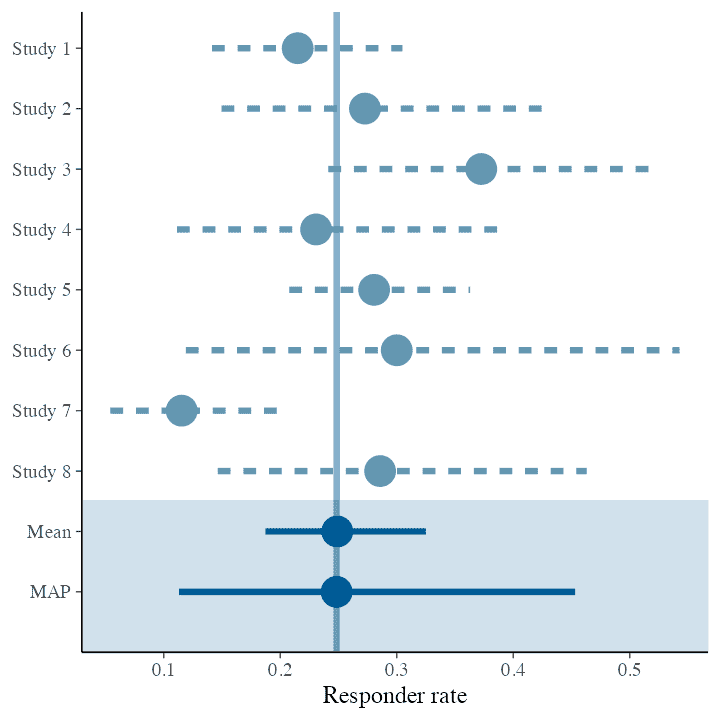

MAP prior:

| mean | median | sd | q2.5 | q50 | q97.5 |
| --- | --- | --- | --- | --- | --- |
| 0.26 | 0.25 | 0.08 | 0.11 | 0.25 | 0.45 |

[^3]: D. Beaten, Lancet, 2013 (382)

## Generalized Meta-Analytic-Predictive model

$Y$ is the (control) group summary data for $H$ historical trials
$$\begin{align*}
Y_{h}|\theta_{h} &\sim f(\theta_{h}) & \forall \; h \in [1,H] \\
Y_\ast|\theta_\ast &\sim f(\theta_\ast) & \text{for new trial}
\end{align*}$$

**Exchangeability assumption**:
$$\begin{align*}
g(\theta_{h})|\beta,\tau &\sim \text{Normal}(\beta, \tau^2) & \forall \; h \in [1,H] \\
g(\theta_\ast)|\beta,\tau &\sim \text{Normal}(\beta, \tau^2) & \text{for new trial}
\end{align*}$$

- $f$ likelihood / $g$ link function: Binomial/logit, Normal (known $\sigma$)/identity or Poisson/log
- $\tau \rightarrow 0 \Rightarrow$ pooling / unbound use of historical data
- $\tau \rightarrow \infty \Rightarrow$ stratification / no use of historical data

## Running the MAP analysis in R

- `RBesT`<sup>1</sup>

```r
library(RBesT)
set.seed(98721487)
map_mc <- gMAP(cbind(r, n-r) ~ 1 | study,
               data=RBesT::AS,
               family=binomial,
               tau.dist="HalfNormal",
               tau.prior=1,
               beta.prior=2)
```

- `brms`

```r
library(brms)
# outcome modifier "| trials(n)" to specify number of trials
# intercept study random effect requested with (1 | study)
bmap_model <- bf(r | trials(n) ~ 1 + (1 | study),
                 family=binomial, center=FALSE)
bmap_model_prior <- prior(normal(0, 2), class=b, coef=Intercept) +
    prior(normal(0, 1), class=sd, coef=Intercept, group=study)
bmap_mc <- brm(bmap_model,
               data=RBesT::AS,
               prior=bmap_model_prior,
               seed=98721487, control=list(adapt_delta=0.99))
```

| study | n | r |
| --- | --- | --- |
| Study 1 | 107 | 23 |
| Study 2 | 44 | 12 |
| Study 3 | 51 | 19 |
| Study 4 | 39 | 9 |
| Study 5 | 139 | 39 |
| Study 6 | 20 | 6 |
| Study 7 | 78 | 9 |
| Study 8 | 35 | 10 |

[^4]: R Bayesian evidence synthesis tools, https://opensource.nibr.com/RBesT/

## `brms` generated Stan code & data

```r
stancode(bmap_mc)
```

```stan
// generated with brms 2.23.0
functions {
}
data {
  int<lower=1> N;  // total number of observations
  array[N] int Y;  // response variable
  array[N] int trials;  // number of trials
  int<lower=1> K;  // number of population-level effects
  matrix[N, K] X;  // population-level design matrix
  // data for group-level effects of ID 1
  int<lower=1> N_1;  // number of grouping levels
  int<lower=1> M_1;  // number of coefficients per level
  array[N] int<lower=1> J_1;  // grouping indicator per observation
  // group-level predictor values
  vector[N] Z_1_1;
  int prior_only;  // should the likelihood be ignored?
}
transformed data {
}
parameters {
  vector[K] b;  // regression coefficients
  vector<lower=0>[M_1] sd_1;  // group-level standard deviations
  array[M_1] vector[N_1] z_1;  // standardized group-level effects
}
transformed parameters {
  vector[N_1] r_1_1;  // actual group-level effects
  // prior contributions to the log posterior
  real lprior = 0;
  r_1_1 = (sd_1[1] * (z_1[1]));
  lprior += normal_lpdf(b[1] | 0, 2);
  lprior += normal_lpdf(sd_1[1] | 0, 1)
    - 1 * normal_lccdf(0 | 0, 1);
}
model {
  // likelihood including constants
  if (!prior_only) {
    // initialize linear predictor term
    vector[N] mu = rep_vector(0.0, N);
    mu += X * b;
    for (n in 1:N) {
      // add more terms to the linear predictor
      mu[n] += r_1_1[J_1[n]] * Z_1_1[n];
    }
    target += binomial_logit_lpmf(Y | trials, mu);
  }
  // priors including constants
  target += lprior;
  target += std_normal_lpdf(z_1[1]);
}
generated quantities {
}
```

```r
standata(bmap_mc)
```

```
$N
[1] 8

$Y
[1] 23 12 19  9 39  6  9 10

$trials
[1] 107  44  51  39 139  20  78  35

$K
[1] 1

$X
  Intercept
1         1
2         1
3         1
4         1
5         1
6         1
7         1
8         1
attr(,"assign")
[1] 0

$Z_1_1
1 2 3 4 5 6 7 8
1 1 1 1 1 1 1 1

$J_1
[1] 1 2 3 4 5 6 7 8

$N_1
[1] 8

$M_1
[1] 1

$NC_1
[1] 0

$prior_only
[1] 0

attr(,"class")
[1] "standata" "list"
```

## Summary MAP prior model

```r
summary(bmap_mc)
```

```
 Family: binomial
  Links: mu = logit
Formula: r | trials(n) ~ 1 + (1 | study)
   Data: RBesT::AS (Number of observations: 8)

Multilevel Hyperparameters:
~study (Number of levels: 8)
              Estimate Est.Error l-95% CI u-95% CI Rhat Bulk_ESS Tail_ESS
sd(Intercept)     0.38      0.21     0.06     0.86 1.00     1186     1616

Regression Coefficients:
          Estimate Est.Error l-95% CI u-95% CI Rhat Bulk_ESS Tail_ESS
Intercept    -1.10      0.19    -1.48    -0.72 1.00     1442     1530
```

- `Intercept` is the typical trial response rate on the logit scale
- `sd(Intercept)` is the between-trial heterogeneity $\tau$

## Predicting the placebo response rate in a new study

```r
AS_new <- data.frame(study = "new_study", n = 1)
pe <- posterior_epred(
    bmap_mc, newdata = AS_new,
    allow_new_levels = TRUE,
    sample_new_levels = "gaussian"
)
summarise_draws(pe)
```

```
# A tibble: 1 × 10
  variable  mean median     sd    mad    q5   q95  rhat ess_bulk ess_tail
  <chr>    <dbl>  <dbl>  <dbl>  <dbl> <dbl> <dbl> <dbl>    <dbl>    <dbl>
1 ...1     0.259  0.249 0.0882 0.0662 0.132 0.416  1.00    3043.    2585.
```

- `allow_new_levels=TRUE` allows to simulate the study random effect for new (unseen) studies
- `sample_new_levels = "gaussian"` ensures that the simulation is done using the normal hierarchical model (the default is to *bootstrap* existing levels)

## Approximation with a finite mixture

For specifying the prior as part of a pre-specified analysis we choose a parametric approximation:

```r
pe_mix <- RBesT::automixfit(pe[, 1], type = "beta")
print(pe_mix, digits=3)
```

```
EM for Beta Mixture Model
Log-Likelihood = 4407.352

Univariate beta mixture
Mixture Components:
  comp1 comp2
w  0.67  0.33
a 16.64  2.99
b 50.26  7.71
```

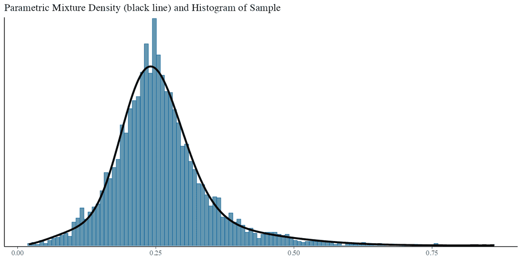

```r
plot(pe_mix)$mix
```

## Region specific MAP prior (hypothetically)

```r
withr::with_seed(654873,
                 AS_region <- bind_cols(AS, region=sample(c("asia", "europe", "north_america"), 8, TRUE)))
kable(AS_region)
```

| study | n | r | region |
| --- | --- | --- | --- |
| Study 1 | 107 | 23 | europe |
| Study 2 | 44 | 12 | asia |
| Study 3 | 51 | 19 | europe |
| Study 4 | 39 | 9 | europe |
| Study 5 | 139 | 39 | asia |
| Study 6 | 20 | 6 | north_america |
| Study 7 | 78 | 9 | europe |
| Study 8 | 35 | 10 | asia |

## Region specific MAP Priors via varying regions model

```r
form_AS_region <- bf(
  r | trials(n) ~ 1 + (1 | region / study),
  family = binomial,
  center = FALSE
)

# show which priors brms defines for this model
get_prior(form_AS_region, AS_region)

bprior_AS_region <- prior(normal(0, 2), class = b, coef = Intercept) +
  prior(normal(0, 0.8), class = sd, coef = Intercept, group = region) +
  prior(normal(0, 0.6), class = sd, coef = Intercept, group = region:study)

fit_AS_region <- brm(
  form_AS_region,
  data = AS_region,
  prior = bprior_AS_region,
  seed = 29856341,
  control = list(adapt_delta = 0.99)
)
```

- `(1 | region/study)` specifies a *nested* random effect as each study is run in a single region. It is equivalent to  
  `(1 | region) + (1 | region:study)`.

## Summary region model

```r
summary(fit_AS_region)
```

```
 Family: binomial
  Links: mu = logit
Formula: r | trials(n) ~ 1 + (1 | region/study)
   Data: AS_region (Number of observations: 8)

Multilevel Hyperparameters:
~region (Number of levels: 3)
              Estimate Est.Error l-95% CI u-95% CI Rhat Bulk_ESS Tail_ESS
sd(Intercept)     0.36      0.32     0.01     1.19 1.00     1360     1596

~region:study (Number of levels: 8)
              Estimate Est.Error l-95% CI u-95% CI Rhat Bulk_ESS Tail_ESS
sd(Intercept)     0.34      0.19     0.03     0.77 1.00     1109      989

Regression Coefficients:
          Estimate Est.Error l-95% CI u-95% CI Rhat Bulk_ESS Tail_ESS
Intercept    -1.07      0.33    -1.69    -0.33 1.00     1792     1879
```

## Extract MAP MCMC samples

```r
AS_region_new <- data.frame(study = "new_study_asia", n = 1, region = "asia")

pe_region <- posterior_epred(
  fit_AS_region,
  newdata = AS_region_new,
  allow_new_levels = TRUE,
  sample_new_levels = "gaussian"
)
summarise_draws(pe_region)
```

```
# A tibble: 1 × 10
  variable  mean median     sd    mad    q5   q95  rhat ess_bulk ess_tail
  <chr>    <dbl>  <dbl>  <dbl>  <dbl> <dbl> <dbl> <dbl>    <dbl>    <dbl>
1 ...1     0.273  0.267 0.0872 0.0667 0.143 0.435  1.00    3564.    3228.
```

## Obtain parametric MAP prior

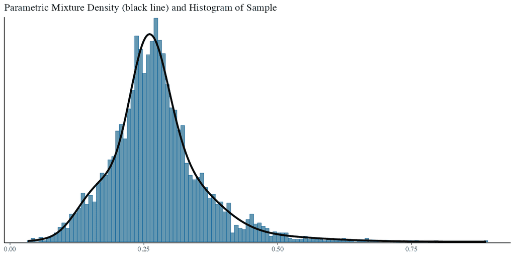

```r
pe_mix_region <- RBesT::automixfit(pe_region[, 1], type = "beta")
plot(pe_mix_region)$mix
```

## Summary historical control data

- Bayesian random-effects meta-analysis models can be used to derive Meta-Analytic-Predictive (MAP) priors
- Predictions for new study mean inform the MAP prior
- Specification and inference for MAP models is simple in `brms`
- Not covered here:
  - Parametric MAP mixtures can be used as priors in `brms` using the `RBesT::mixstanvar` adapter ([check its documentation](https://opensource.nibr.com/RBesT/reference/mixstanvar.html)), also refer to the case study [Use of historical control data with stratification](https://opensource.nibr.com/bamdd/src/02ac_meta_analysis_strata.html)
  - Prior setup, coming up next and also refer to [model description](https://opensource.nibr.com/bamdd/src/02a_meta_analysis.html#model-description) section of respective historical control case study

# Hands-on exercises: historical control data

# Priors

## The prior can only be understood in the context of the model <sup>1</sup>

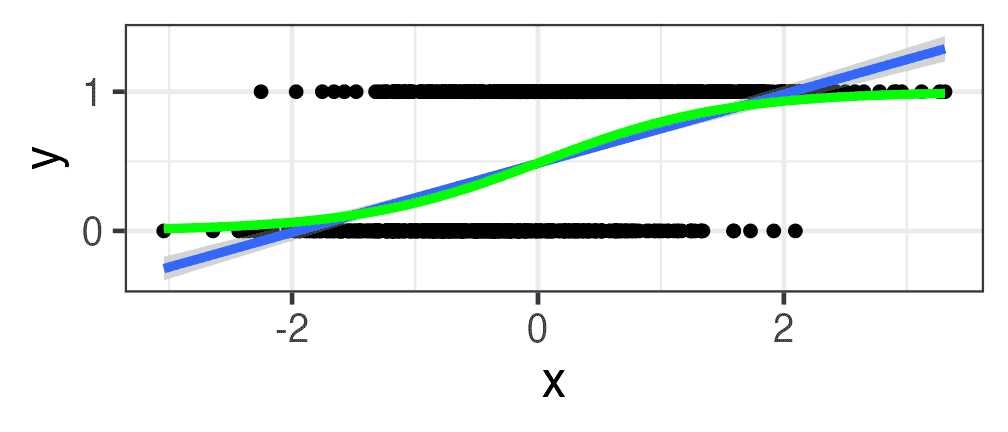

[^5]: Further reading: Gelman, A., Simpson, D., & Betancourt, M. (2017). The prior can often only be understood in the context of the likelihood. *Entropy*.

## Commonly heard reasons to be afraid of priors

“Priors are inherently subjective”

“Priors bias your analysis”

“You should let the data speak for themselves”

“Non-Bayesian models don’t have priors and don’t need them”

“I have no idea how to set appropriate priors”

## Are priors inherently subjective?

Consider using the alternative terms “contextual” or “conditional”<sup>1</sup>

- on the person or people or agent performing the analysis
- on results of previous studies
- on structural assumptions
- …
[^6]: Further reading: Christen, J. A. (2006). Stop using ‘subjective’ to refer to Bayesian analyses (comment on articles by Berger and by Goldstein). *Bayesian Analysis*.

## Do priors bias your analysis?

*Definition*:

An estimator $\hat{\theta}$ of the parameter $\theta$ is called *unbiased* if $\text{E}_{y}(\hat{\theta}) = \theta$.

*Corrollary*:

If an estimator $\hat{\theta}$ is unbiased for a given prior, it will be biased for most other priors.

*Corrollary*:

If an estimator $\hat{\theta}$ is unbiased at a given scale, it will be biased for most non-linear transformations $f(\hat{\theta})$ (Jensen’s inequality):
$$\text{E}_y(f(\hat{\theta})) \neq f(\theta)$$

**Unbiasedness is fragile and often only holds in the limit**

## Is bias even the right metric?

A sampling distribution is a distribution of a data-dependent variable (a “statistic”) as implied by variation in data $y$ across the true data generating process

Consider two estimators $\hat{\theta}_1$ and $\hat{\theta}_2$ of $\theta$ with sampling distributions given by

- $p(\hat{\theta}_1) := p(\hat{\theta}_1(y)) = \text{Normal}(\theta, 10)$
- $p(\hat{\theta}_2) := p(\hat{\theta}_2(y)) = \text{Normal}(\theta + 0.2, 1)$

Which of them is better?

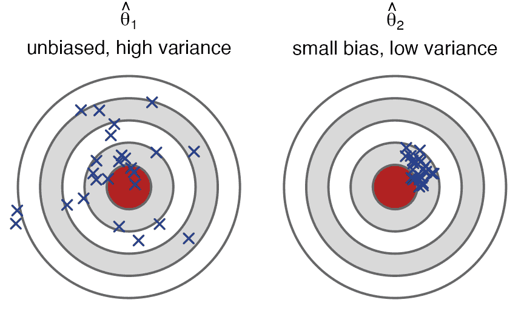

## Winning the bias-variance trade-off

The RMSE can be defined as
$$\begin{align*}
\text{RMSE}_y(\hat{\theta}, \theta) & = \sqrt{\int (\hat{\theta}(y) - \theta)^2 \; p(y) \; d y} \\
& = \sqrt{\text{Var}_y{\hat{\theta}} + \text{Bias}_y(\hat{\theta}, \theta) ^2}
\end{align*}$$

It expresses a trade-off between variance and bias

A lot of priors will help you win the bias-variance trade-off, not the race for minimal bias!

## Prior tails

What is the posterior?

- … if the prior is
  $$\theta \sim \text{student-t}(4, 5, 1)$$
- … and the likelihood alone implies a posterior of
  $$\theta \sim \text{normal}(-5, 1)$$

## Student-t(4) prior vs. normal likelihood

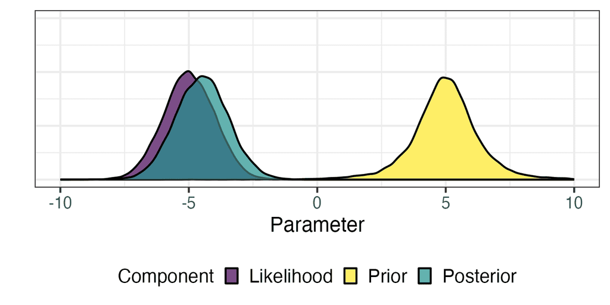

## Normal prior vs. student-t(4) likelihood

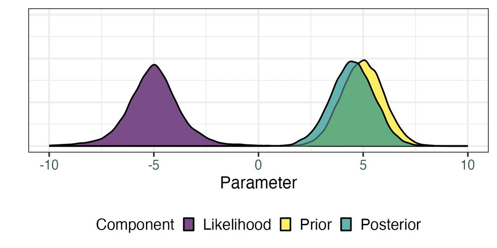

## Normal prior vs. normal likelihood

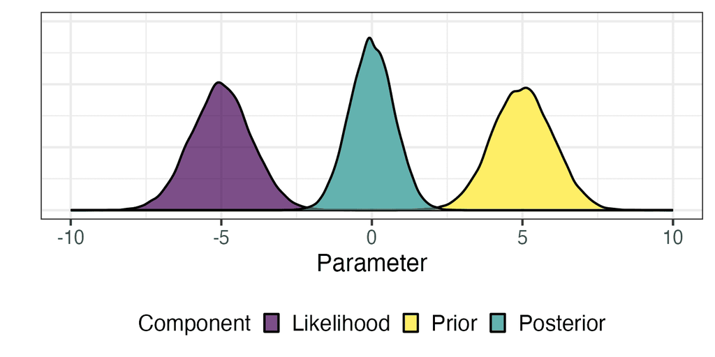

## Student-t(4) prior vs. student-t(4) likelihood

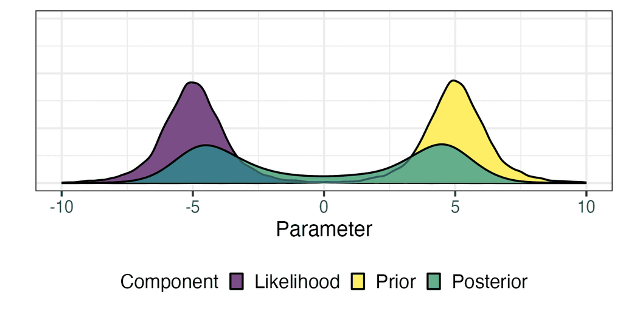

## Principles of specifying priors

- Respecting boundaries: use hard bounds in priors exactly where parameters have natural bounds
- Expressiveness: use prior families flexible enough to express different plausible prior knowledge
- Controlling complexity: If you want to be conservative, put relevant amount of prior probability at or near a conservative submodel
- Scale awareness: ensure that priors take the scales and measurement unit of parameters into account
- Reflecting structure: reflect the structure of the data in the structure of the prior
- **Data Informed**: Use previous data to inform the current priors

## Data informed priors

- The [`RBesT` package](https://opensource.nibr.com/RBesT/) allows to build Meta-Analytic-Predictive (MAP) priors, a special kind of data informed priors
- See the ESMARConf2023 tutorial for `RBesT` on [Youtube](https://www.youtube.com/watch?v=w90j-PLwWDc)
- Also check out https://opensource.nibr.com/bamdd/ for the following MAP case studies: [**historical control** without](https://opensource.nibr.com/bamdd/src/02a_meta_analysis.html) / [with **stratification**](https://opensource.nibr.com/bamdd/src/02ac_meta_analysis_strata.html), [treatment effects](https://opensource.nibr.com/bamdd/src/02ab_meta_analysis_trtdiff.html), [**single arm PoS**](https://opensource.nibr.com/bamdd/src/02l_single_arm_pos.html)

## “Non-informative” uniformity is informative!

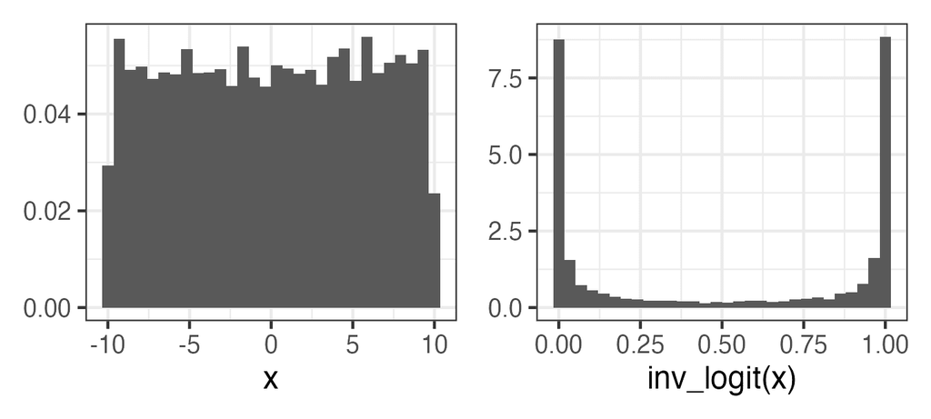

## Evaluating and comparing priors

- Consider the **unit** of a parameter
- Visualize the prior
- Categorization of parameter into **ranges**
- Comparisons of priors through  
  **interval probabilities**

**Example:** Binary response rates for a non-rare or frequent event

| Category | Percentage range |
| --- | --- |
| Extreme | 0–1% & 99–100% |
| Very Small | 1–5% & 95–99% |
| Small | 5–10% & 90–95% |
| Moderate | 10% – 90% |

## Prior visualization of a log-odds intercept

Example default priors

**wide**

Normal($0$, $10^2$)

**`brms`**

Student-t($3$, $0$, $2.5^2$)

**`RBesT`**

Normal($0$, $2^2$)

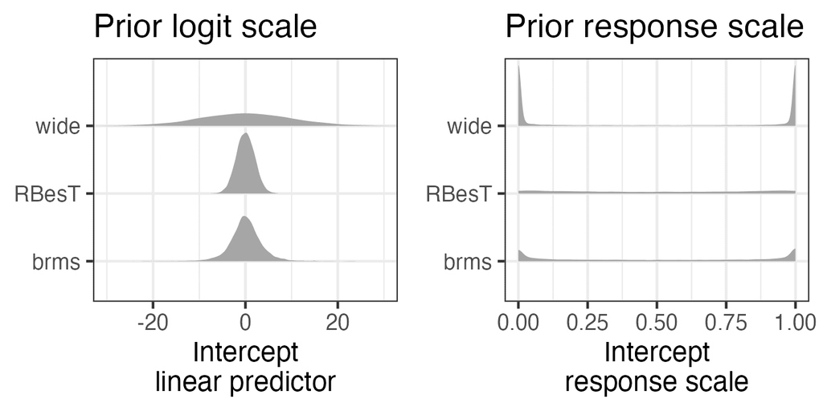

## Prior intervals of a log-odds intercept

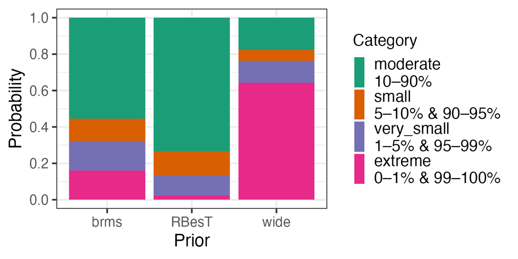

## Worked example: priors for a phase I dose-escalation model

Phase I trials in oncology start with limited knowledge on the toxicity of a new treatment:

- patients are enrolled in **small cohorts** (1–6 patients), starting at a dose that is very likely safe
- the dose is then **increased systematically**, as quickly as possible to reach active doses, and as safely as possible such that **dose-limiting toxicities (DLTs)** are controlled

**Goal:** a safe dosing range for further development, keeping the DLT rate of trial and future patients below 33%.

We use this setting to work through **setting up a prior from scratch**.

## Bayesian Logistic Regression Model (BLRM)

$$\begin{align*}
Y_i \mid \pi(d_i), n_i &\sim \text{Binomial}(\pi(d_i), n_i) \\
\text{logit}(\pi(d_i)) &= \log(\alpha) + \beta \, \log(d_i / d_{\text{ref}})
\end{align*}$$

- $Y_i$: number of DLTs observed out of $n_i$ patients during the first cycle at dose $d_i$
- $d_{\text{ref}}$: reference dose, chosen by us
- $\alpha$: odds of a DLT at $d_i = d_{\text{ref}}$
- $\beta$: slope, constrained to be positive (more dose, more toxicity)

## Escalation With Overdose Control (EWOC)

$$\pi(d) \in
\begin{cases}
[0, 0.16] & \text{underdose} \\
(0.16, 0.33] & \text{target dose} \\
(0.33, 1] & \textcolor{red}{\text{overdose}}
\end{cases}$$

EWOC criterion<sup>1</sup>: dose $d$ is allowed only if $\Pr(\pi(d) \in \textcolor{red}{\text{overdose}}) < 1/4$.

A dose is not allowed if we are confident that it overdoses, **or** if we are too uncertain about it: the **prior matters** for which doses are allowed early on.

[^7]: Babb J, Rogatko A, Zacks S (1998). *Stat Med* 17(10):1103–20.

## Motivating the dose-DLT curve prior

The starting dose and the planned dose grid already encode a strong, asymmetric belief:

- The **starting dose** is chosen such that it **is very likely safe**
- **Uncertainty grows towards higher doses**

**The doses we plan to study *imply* a prior!**

We also have *a priori* expectations on how the model should react to the first cohorts.

## Expectations on initial data scenarios

With a first **cohort of size 3**, the 3+3 rules are a sensible benchmark **at the starting dose**:

- **0/3** DLTs $\rightarrow$ **allowed to escalate** to 2 $\times$ dose
- **1/3** DLTs $\rightarrow$ **allowed to stay**
- **2/3** DLTs $\rightarrow$ **should (be able to) de-escalate** to half the dose
- **3/3** DLTs $\rightarrow$ **should (be able to) de-escalate** by more than half the dose

For **cohorts of size one**, at the starting dose:

- If **patient one** has a **DLT**, we should be able to **stay and recruit one more patient**
- If **patient two** also has a **DLT**, **de-escalation** to half the dose should be **required & allowed**

**Repeatedly observing 0/3 DLTs should allow escalating freely** to the next dose level. Such data scenarios are checks the prior has to pass.

## How do we set our priors?

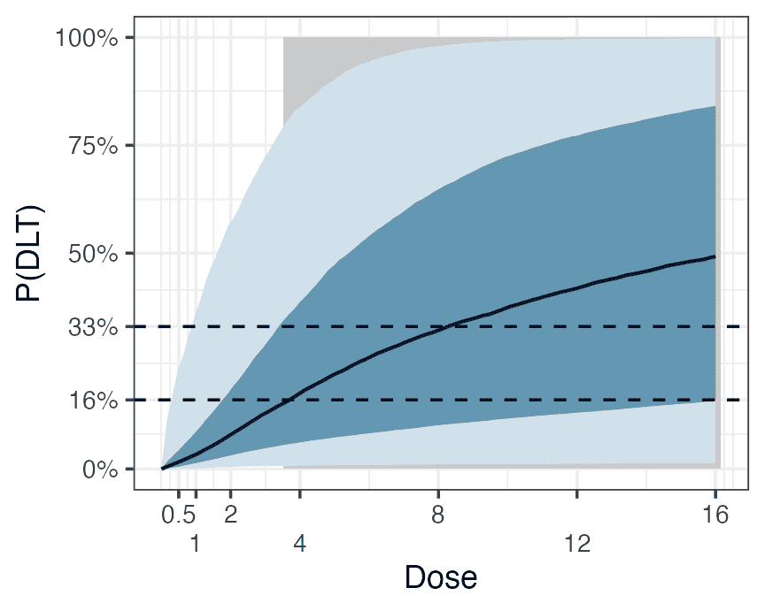

Prior median, 50% and 95% intervals of $\pi(d)$; greyed doses violate EWOC.

$$\begin{align*}
Y_i \mid \pi(d_i), n_i &\sim \text{Binomial}(\pi(d_i), n_i) \\
\text{logit}(\pi(d)) &= \log(\alpha) + \beta \log(d/d_{\text{ref}})
\end{align*}$$

Prior for the intercept $\log(\alpha)$ and the log-slope $\log(\beta)$:

$$(\log(\alpha), \log(\beta)) \sim \text{MultiNormal}(\boldsymbol{m}, \boldsymbol{S})$$

I.e., we need to choose the

- reference dose $d_{\text{ref}}$
- means $\boldsymbol{m}$ of $\log(\alpha)$ and $\log(\beta)$
- covariance $\boldsymbol{S}$: SDs $\sigma$ and correlation $\rho$

## Choosing the reference dose and intercept

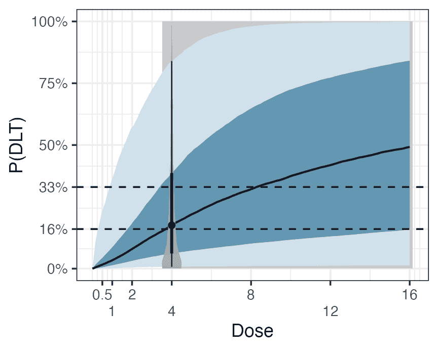

$\alpha$ determines the odds of a DLT at the reference dose $d_{\text{ref}}$:

$$\text{logit}(\pi(d_{\text{ref}})) = \log(\alpha) + \underbrace{\beta \log(d_{\text{ref}}/d_{\text{ref}})}_{=0}$$

Here, the starting dose is $d_\text{start} = 1$, the reference dose $d_{\text{ref}}= 4$, and

$$\log(\alpha) \sim \text{Normal}(\text{logit}(0.17), 1.7^2)$$

as shown by the violin plot.

## What does changing the slope do?

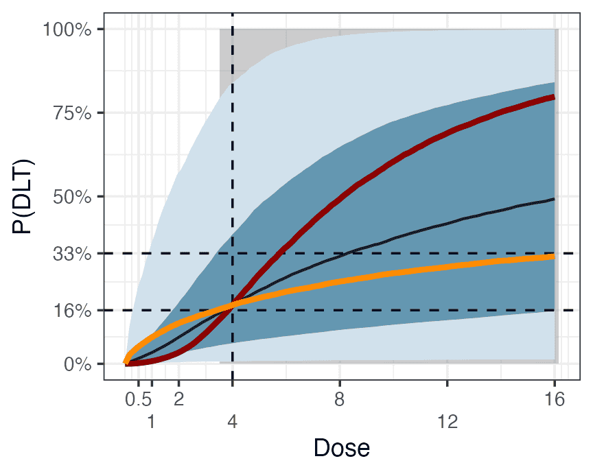

Varying the mean slope from 1/2 to 1 to 2: all median curves meet at the reference dose (dashed line) and the intercept prior.

## Extreme slopes are not realistic

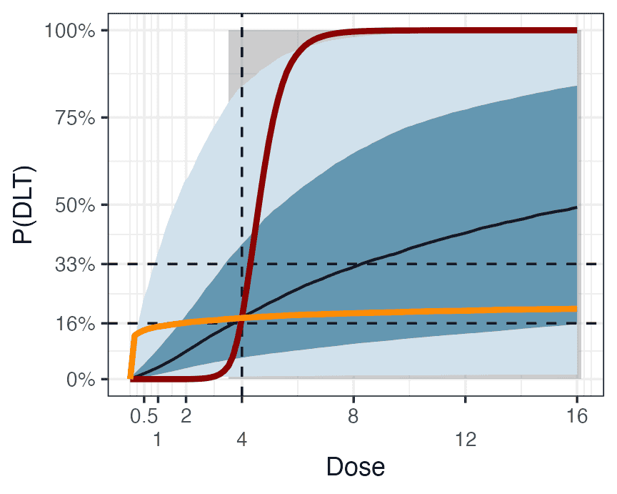

Slopes such as 1/10 or 10 are biologically implausible and should get little prior mass. On the probability scale:

$$\pi(d) = \frac{\alpha (d/d_{\text{ref}})^\beta}{1 + \alpha(d/d_{\text{ref}})^\beta}$$

- Flat curve: for $\beta \rightarrow 0$, $\pi(d) \rightarrow \alpha/(1 + \alpha)$ at every dose
- Step function: for $\beta \rightarrow \infty$, $\pi(d < d_{\text{ref}}) \rightarrow 0$ and $\pi(d > d_{\text{ref}}) \rightarrow 1$

## Plot priors to inspect them for plausibility!

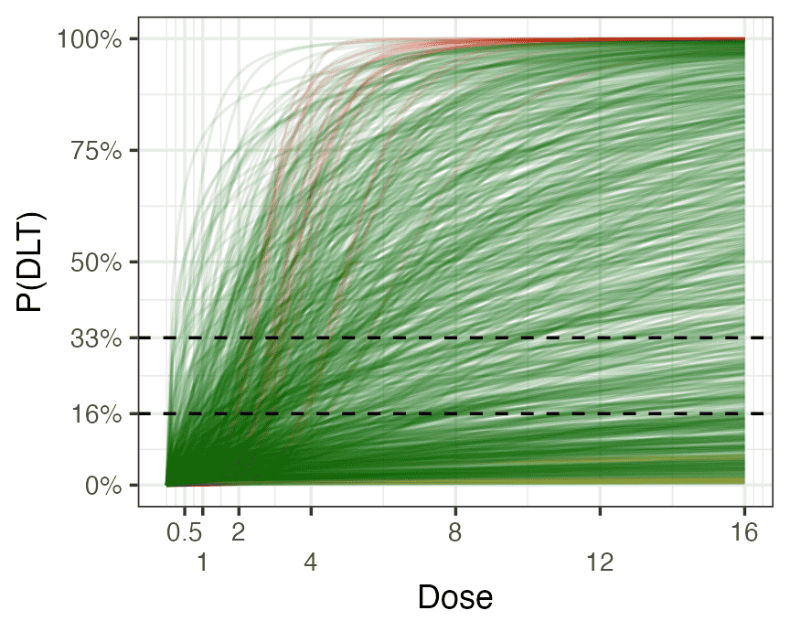

**Rule of thumb:** biologically plausible dose-DLT slopes lie between 1/4 and 4.

Putting 95% of the prior mass there:

$$\log(\beta) \sim \text{Normal}(\log(1), (\underbrace{\log(4)/1.96}_{\approx 0.7})^2)$$

gives<sup>1</sup>

94.3% reasonable slopes (1/4 to 4)  
2.9% flat (slope < 1/4)  
2.8% step functions (slope > 4)

The Hill parameter prior of the dose-finding exercises uses the same rule.

[^8]: Monte Carlo estimates from 4000 prior draws.

## Be careful with high slope prior variance …

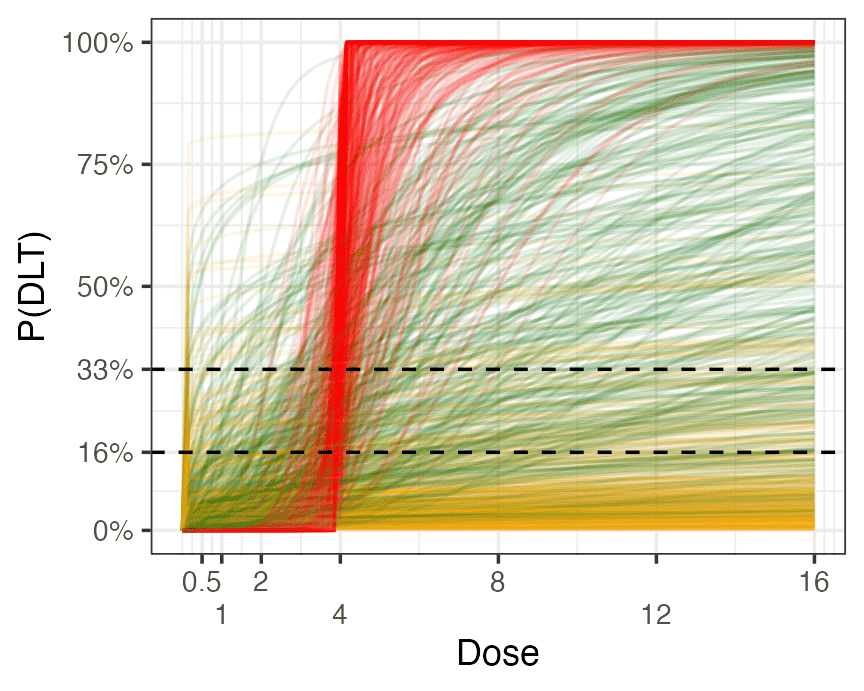

$$\log(\beta) \sim \text{Normal}(\log(1), \textcolor{red}{3}^2)$$

34.7% reasonable slopes (1/4 to 4)  
32.6% flat (slope < 1/4)  
32.7% step functions (slope > 4)

A “vague” slope prior is **not** uninformative: it mostly says the dose-DLT curve is flat or a step function.

## … because adding data will not overrule that …

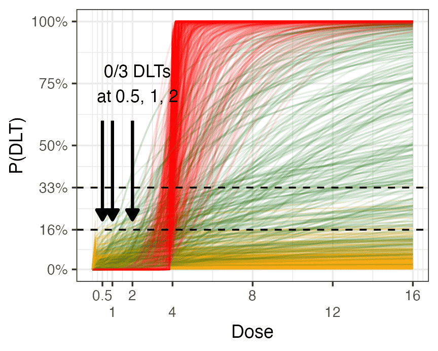

$$\log(\beta) \sim \text{Normal}(\log(1), \textcolor{red}{3}^2)$$

after 0/3 DLTs at each of 0.5, 1, 2:

30.1% reasonable slopes (1/4 to 4)  
25.4% flat (slope < 1/4)  
44.5% step functions (slope > 4)

Three small cohorts at low doses say little about the slope; the step functions just above the tested doses even gain mass.

## … just use a reasonable prior!

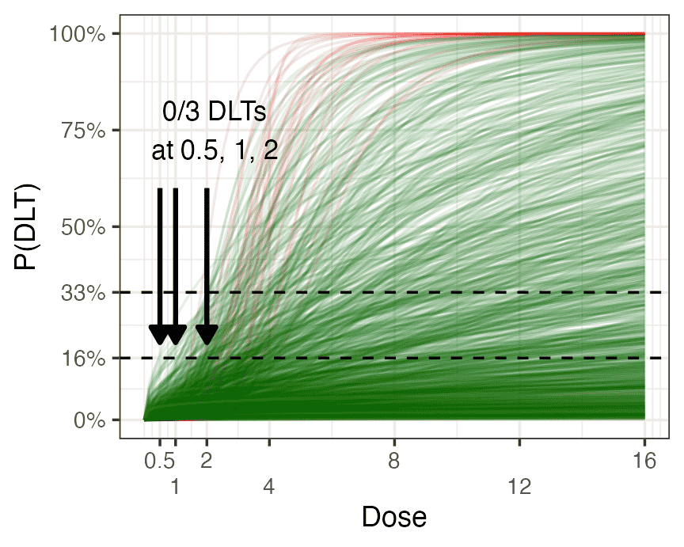

$$\begin{align*}
d_{\text{ref}}&= 4 \\
\log(\alpha) &\sim \text{Normal}(\text{logit}(0.17), 1.7^2) \\
\log(\beta) &\sim \text{Normal}(\log(1), (\log(4)/1.96)^2) \\
\rho &= 0.6
\end{align*}$$

after 0/3 DLTs at each of 0.5, 1, 2:

94.3% reasonable slopes (1/4 to 4)  
2.5% flat (slope < 1/4)  
3.3% step functions (slope > 4)

## Implementing the BLRM prior in `brms`

```r
blrm_model <- bf(num_toxicities | trials(num_patients) ~ logalpha + exp(logbeta) * log(Dose / dref),
                 logalpha + logbeta ~ 1, nl = TRUE, family = binomial())

# brms has no bivariate normal prior across non-linear parameters, so we add it to the target
prior <- list(m = c(logit_scaled(0.17), log(1)), s = c(1.7, log(4) / 1.96), r = 0.6)
stanvars <- stanvar(prior$m, "M") + stanvar(prior$s, "S") + stanvar(prior$r, "rho") +
  stanvar(scode = "matrix[2, 2] L = [[S[1], 0], [rho * S[2], sqrt(1 - rho^2) * S[2]]];",
          block = "tdata")
mvn_prior <- prior("target += multi_normal_cholesky_lpdf([b_logalpha[1], b_logbeta[1]]' | M, L)",
                   check = FALSE)

data <- tibble(Dose = c(0.5, 1, 2), num_patients = 3, num_toxicities = 0, dref = 4)
fit <- brm(blrm_model, data = data, prior = mvn_prior, stanvars = stanvars)
```

- `sample_prior = "only"` refuses this hand-written prior. To sample from the prior, fit a data set with `num_patients = 0` instead, or simulate with `mvtnorm::rmvnorm()`.
- [`OncoBayes2`](https://opensource.nibr.com/OncoBayes2) implements this model (and combination therapies) ready to use.

## Take-aways from the BLRM example

- The planned dose grid **implies** a prior on the dose-DLT curve
- **Plot** the prior on the outcome scale and check it against expected initial data scenarios
- “Vague” priors on a log-slope are **informative** in all the wrong places, and a few cohorts will not fix that
- The lowest and highest dose of the grid can be used to **calibrate** the prior<sup>1</sup>
[^9]: Widmer, L. A., Bean, A., & Weber, S. (2026). Design-informed prior calibration for BLRM and E<sub>max</sub> models in oncology phase I dose escalation trials. ISCB 2026. https://luwidmer.github.io/iscb2026-prior-calibration

# Dose finding

## Typical dose response shapes

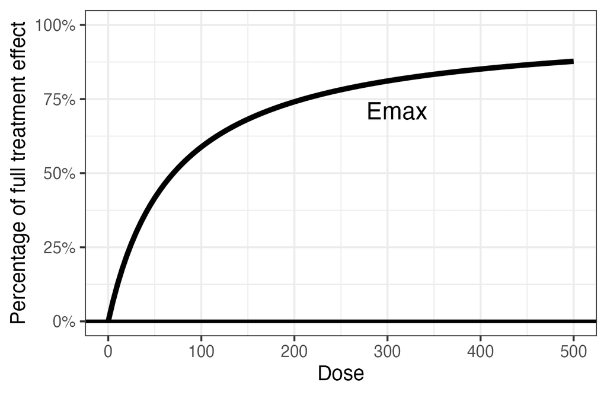

## Typical dose response shapes

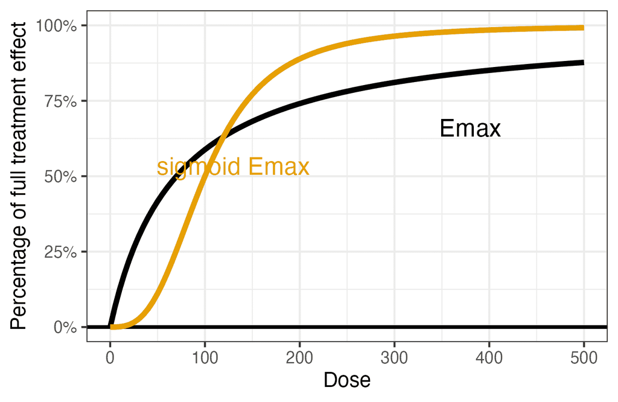

## Typical dose response shapes

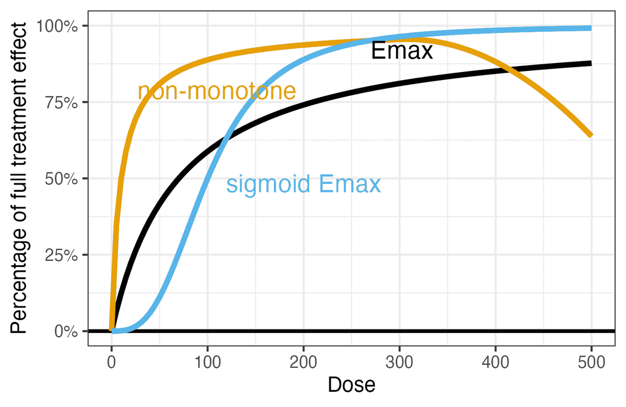

## Data Set PATHWAY

- Placebo controlled trial
- Treatment of severe asthma with tezepelumab
- Three different doses + placebo
- Endpoint: annualized rate of asthma exacerbations
- Estimates per arm from negative binomial regression (like in “arm-based meta-analysis”), not individual patient data

| dose | group | log_est | log_stderr |
| --- | --- | --- | --- |
| 0 | placebo | −0.400 | 0.103 |
| 70 | tezepelumab 70 mg q4w | −1.347 | 0.177 |
| 210 | tezepelumab 210 mg q4w | −1.661 | 0.222 |
| 560 | tezepelumab 280 mg q2w | −1.514 | 0.191 |

## Data Set PATHWAY

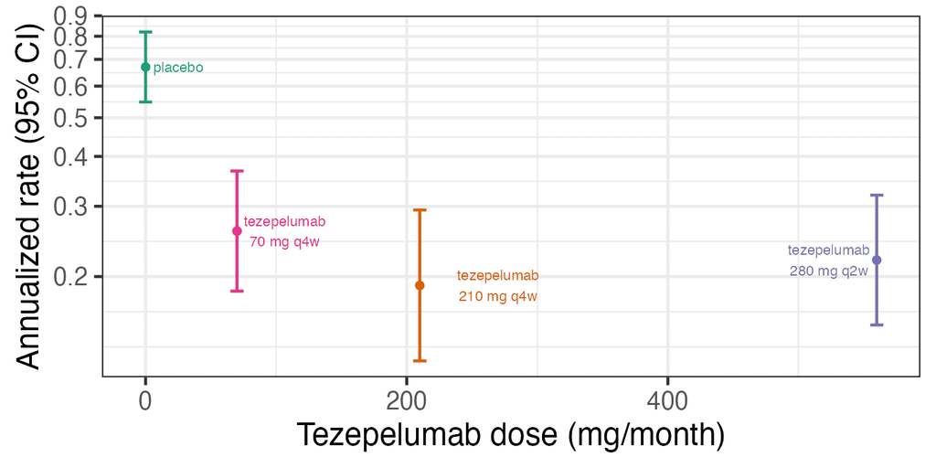

## Sigmoid E<sub>max</sub> Model

$$f(\text{dose}) = \text{E}_0 + \text{E}_\text{max} \, \frac{\text{dose}^h}{\text{dose}^h + \text{ED}_{50}^h}$$

$$\Leftrightarrow f(\text{dose}) = \text{E}_0 + \text{E}_\text{max} \, \text{logit}^{-1}[h \, (\log(\text{dose}) - \log(\text{ED}_{50}))]$$

- $\text{E}_0 \in \mathbb{R}$: Expected placebo outcome
- $\text{E}_\text{max} \in \mathbb{R}$: Maximum effect size
- $h \in \mathbb{R}_+$: Hill (steepness) parameter
- $\text{ED}_{50}$: Dose at which 50% of $\text{E}_\text{max}$ is reached

## The BLRM is a sigmoid E<sub>max</sub> model

The BLRM from the priors section,

$$\begin{align*}
\pi(d) &= \text{logit}^{-1}[\log(\alpha) + \beta \log(d / d_{\text{ref}})] \\
&= \text{logit}^{-1}[\beta\,(\log(d) - \log(\text{TD}_{50}))]
\end{align*}$$

with $\text{TD}_{50} = d_{\text{ref}}\, \alpha^{-1/\beta}$, is the sigmoid E<sub>max</sub> model on the **probability scale** with $\text{E}_0 = 0$, $\text{E}_\text{max} = 1$, $h = \beta$ and $\text{ED}_{50} = \text{TD}_{50}$, the dose with 50% DLT risk.

Hence the 1/4 to 4 rule of thumb for $\beta$ is also a sensible default for the Hill parameter $h$, as used in the dose-finding exercises.

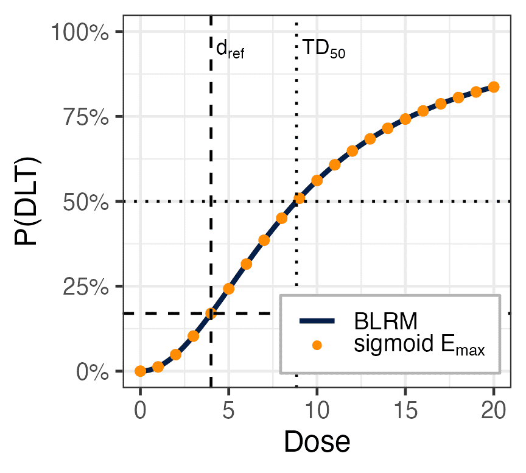

## Sigmoid E<sub>max</sub> Model: Visualization

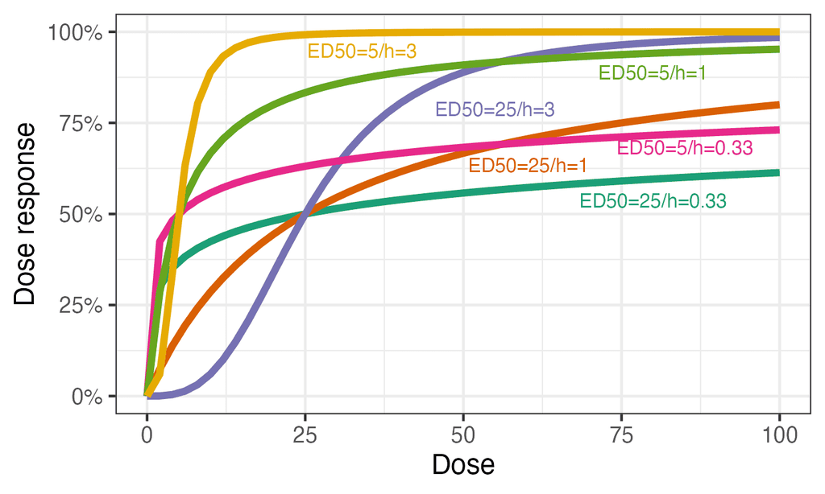

## Specifying sigmoid E<sub>max</sub> Model with `brms`

```r
form_sig <- bf(
  log_est | se(log_stderr) ~ E0 + Emax * dose^h / (dose^h + ED50^h),
  nlf(h ~ exp(logh)),
  nlf(ED50 ~ exp(logED50)),
  E0 ~ 1,
  Emax ~ 1,
  logh ~ 1,
  logED50 ~ 1,
  nl = TRUE,
  family = gaussian()
)

prior_sig <- prior(normal(0, 1), nlpar = E0) +
  prior(normal(0, 1), nlpar = logh) +
  prior(normal(0, 1), nlpar = Emax) +
  prior(normal(4, 2), nlpar = logED50)
```

## A note on E<sub>max</sub> Model priors

What is more informative?

- $\text{logh} \sim \text{normal}(0,1)$
- $\text{logh} \sim \text{normal}(0,3)$

## A note on E<sub>max</sub> Model priors

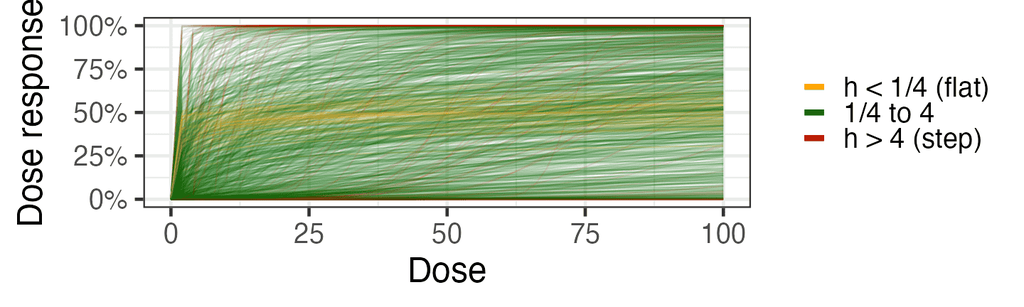

## A note on E<sub>max</sub> Model priors

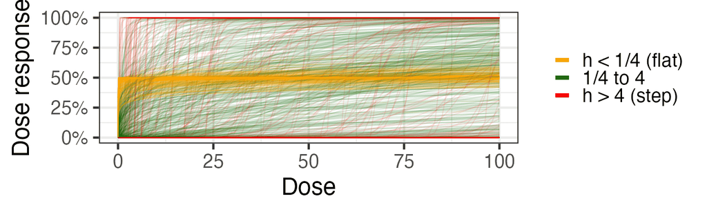

- Biologically plausible values: approx. $.25 < h < 4$ (see [prior interval probabilities](https://opensource.nibr.com/bamdd/src/01c_priors.html)).  
  The above prior puts roughly 1/3 above 4 and 1/3 below 0.25!
- Re-writing the fraction to $\left(\frac{d}{\text{ED}_{50}}\right)^h / \left(1+\left(\frac{d}{\text{ED}_{50}}\right)^h\right)$ makes it obvious that for $h \rightarrow 0$, this goes to $1/2$, and for $h \rightarrow \infty$, either to 0 ($d < \text{ED}_{50}$) or 1 ($d > \text{ED}_{50}$).

## Fitting the sigmoid E<sub>max</sub> Model with `brms`

```r
fit_sig <- brm(
  formula = form_sig,
  data = pathway,
  prior = prior_sig,
  control = list(adapt_delta = 0.99),
  refresh = 0,
  seed = 34565
)
```

## Results Summary Sigmoid E<sub>max</sub> Model

```r
summary(fit_sig)
```

```
 Family: gaussian
  Links: mu = identity
Formula: log_est | se(log_stderr) ~ E0 + Emax * dose^h/(dose^h + ED50^h)
         h ~ exp(logh)
         ED50 ~ exp(logED50)
         E0 ~ 1
         Emax ~ 1
         logh ~ 1
         logED50 ~ 1
   Data: pathway (Number of observations: 4)

Regression Coefficients:
                  Estimate Est.Error l-95% CI u-95% CI Rhat Bulk_ESS Tail_ESS
E0_Intercept         -0.42      0.10    -0.61    -0.22 1.00     2190     2075
Emax_Intercept       -1.30      0.33    -2.16    -0.84 1.00     1211     1021
logh_Intercept       -0.05      0.98    -1.90     1.83 1.00     1360     1913
logED50_Intercept     2.77      1.37    -0.26     5.38 1.00     1102      952

Further Distributional Parameters:
      Estimate Est.Error l-95% CI u-95% CI Rhat Bulk_ESS Tail_ESS
sigma     0.00      0.00     0.00     0.00   NA       NA       NA
```

## Posterior vs Prior Sigmoid E<sub>max</sub> Model

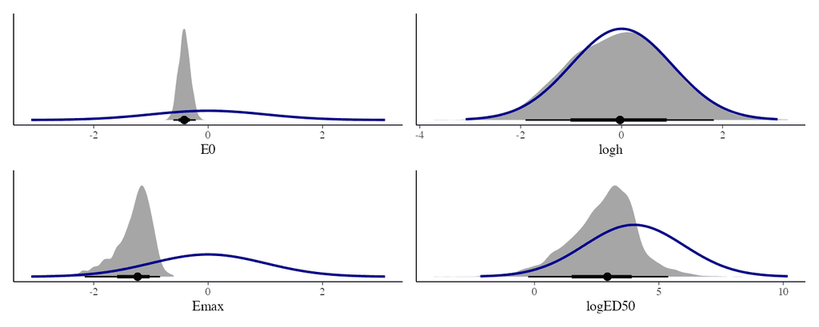

## Visualizing the Fitted Sigmoid E<sub>max</sub> Model

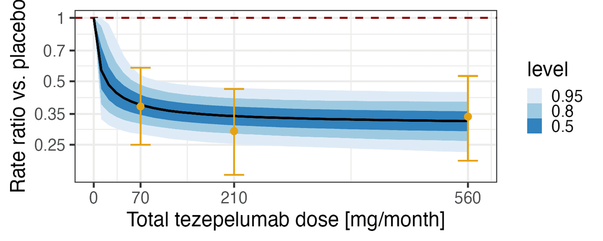

```r
tibble(dose = seq(0, 560, length.out = 51), log_stderr = 1) |>
  tidybayes::add_epred_rvars(object = fit_sig) |>
  mutate(.delta = .epred - .epred[dose == 0]) |>
  ggplot(aes(x = dose, ydist = .delta)) +
  ggdist::stat_lineribbon()
```

## Modified Beta Model

$$f(\text{dose}) = \text{E}_0 +
\text{E}_\text{max} \; \frac{(\delta_1 + \delta_2)^{(\delta_1+\delta_2)}} {\delta_1^{\delta_1} \, \delta_2^{\delta_2}} \; \left(\frac{\text{dose}}{S}\right)^{\delta_1} \left(1-\frac{\text{dose}}{S}\right)^{\delta_2}$$

- $\text{E}_0 \in \mathbb{R}$: Expected placebo response
- $\text{E}_\text{max} \in \mathbb{R}$: Maximum effect size
- $\delta_1, \delta_2 \in \mathbb{R}_+$: Shape parameters
- $S$: constant > maximum dose, e.g. $1.5 \times \max(\text{dose})$, here we choose `S=850`

## Specifying the Modified Beta Model with `brms`

```r
form_mbeta <- bf(
  log_est | se(log_stderr) ~
    E0 +
      Emax *
        (delta1 + delta2)^(delta1 + delta2) /
        (delta1^delta1 * delta2^delta2) *
        (dose / 850)^delta1 *
        (1 - dose / 850)^delta2,
  nlf(delta1 ~ exp(logdelta1)),
  nlf(delta2 ~ exp(logdelta2)),
  E0 ~ 1,
  Emax ~ 1,
  logdelta1 ~ 1,
  logdelta2 ~ 1,
  nl = TRUE,
  family = gaussian()
)

prior_mbeta <- prior(normal(0, 1), nlpar = E0) +
  prior(normal(0, 1), nlpar = Emax) +
  prior(normal(0, 1), nlpar = logdelta1) +
  prior(normal(0, 1), nlpar = logdelta2)
```

## Fitting the Modified Beta Model with `brms`

```r
fit_mbeta <- brm(
  form_mbeta,
  data = pathway,
  prior = prior_mbeta,
  control = list(adapt_delta = 0.99),
  seed = 24355,
  refresh = 0
)
```

## Visualizing the Fitted Modified Beta Model

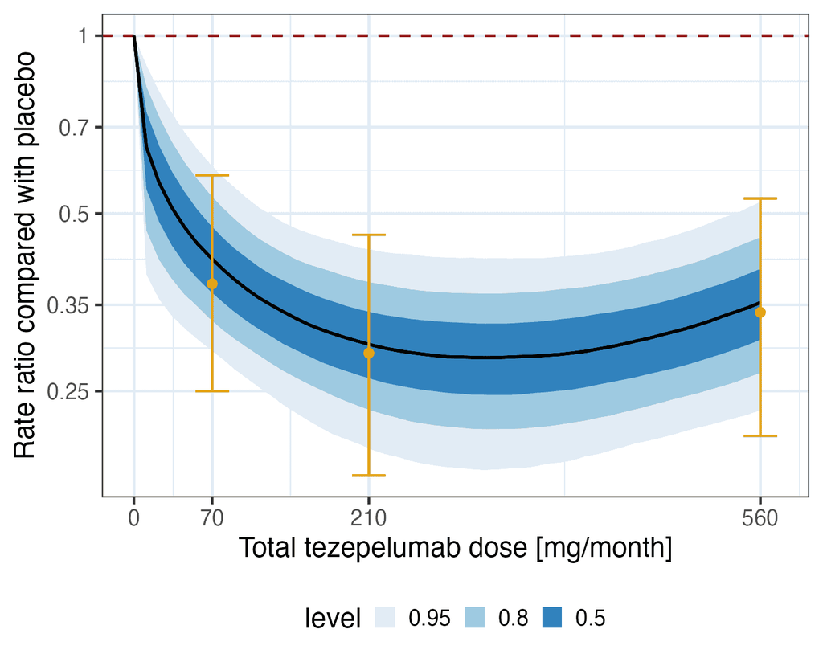